# Индивидуальный проект

Четвертый этап

Устинова В. В.

Российский университет дружбы народов, Москва, России

01 мая 2026

# Информация

## Докладчик

- Устинова Виктория Вадимовна
- студент НПИбд-01-24
- Российский университет дружбы народов

## Цель работы

Научиться основным способам использования nikto

## Задание

1. nikto — базовый сканер безопасности веб-сервера. Он сканирует и обнаруживает уязвимости в веб-приложениях, обычно вызванные неправильной конфигурацией на самом сервере, файлами, установленными по умолчанию, и небезопасными файлами, а также устаревшими серверными приложениями.

## Выполнение лабораторной работы

Проверяем скачан ли nikto

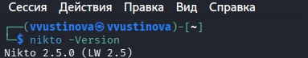

Так как мы видим его версию, соответсвенно он скачан

## Выполнение лабораторной работы

Проверяем какие утилиты у него есть

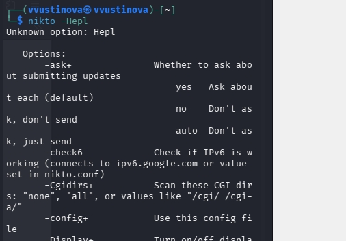

Смотрим основные команды снизу

## Выполнение лабораторной работы

Вводим основную команду и смотрим вывод

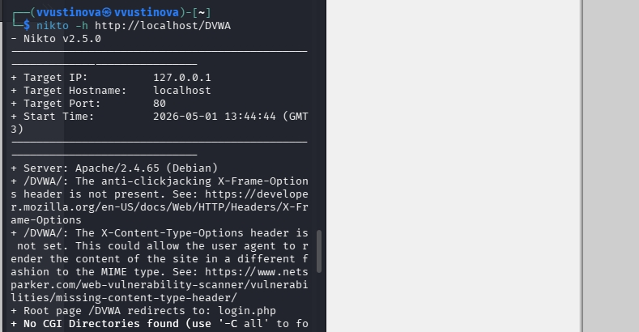

Следующий слайд

## Продолжение

1. The anti-clickjacking X-Frame-Options header is not present. сайт не запрещает другим сайтам вставлять себя во фрейм. Этим могут воспользоваться злоумышленники: они поместят ваш сайт внутрь своего сайта, а поверх наложат невидимые кнопки. Когда вы будете кликать по картинкам, на самом деле будете нажимать на скрытую кнопку «Перевести деньги». Это называется clickjacking.
2. The X-Content-Type-Options header is not set. Браузер иногда сам угадывает тип файла (например, файл .txt пытается выполнить как JavaScript). Хакеры могут этим воспользоваться, загрузив на сайт картинку, внутри которой написан вредоносный скрипт. Браузер может по ошибке выполнить его.

## Выводы

Мы научились основным способам использования nikto